# Fast Kalman Filter

To demonstrate the use of the `FKF` package this example shows how to fit an ARMA(2, 1) model using this Kalman filter implimentation and teh extraction of the resulting filtered and smoothed estimates.

Start by loading the package:

```r
library('FKF')
```

# Generating synthetic data

```r
n <- 1000

## Set the AR parameters
ar1 <- 0.6
ar2 <- 0.2
ma1 <- -0.2
sigma <- sqrt(2)

a <- arima.sim(model = list(ar = c(ar1, ar2), ma = ma1), n = n,
               innov = rnorm(n) * sigma)
```

# Estimation

To estimate the parameters using numerical optimisation two functions are specified. The first creates a state space representation out of the four ARMA parameters

```r
arma21ss <- function(ar1, ar2, ma1, sigma) {
    Tt <- matrix(c(ar1, ar2, 1, 0), ncol = 2)
    Zt <- matrix(c(1, 0), ncol = 2)
    ct <- matrix(0)
    dt <- matrix(0, nrow = 2)
    GGt <- matrix(0)
    H <- matrix(c(1, ma1), nrow = 2) * sigma
    HHt <- H %*% t(H)
    a0 <- c(0, 0)
    P0 <- matrix(1e6, nrow = 2, ncol = 2)
    return(list(a0 = a0, P0 = P0, ct = ct, dt = dt, Zt = Zt, Tt = Tt, GGt = GGt,
                HHt = HHt))
}
```

The second is the objective function passed to `optim` which returns the noegative log-likelihood

```r
objective <- function(theta, yt) {
    sp <- arma21ss(theta["ar1"], theta["ar2"], theta["ma1"], theta["sigma"])
    ans <- fkf(a0 = sp$a0, P0 = sp$P0, dt = sp$dt, ct = sp$ct, Tt = sp$Tt,
               Zt = sp$Zt, HHt = sp$HHt, GGt = sp$GGt, yt = yt)
    return(-ans$logLik)
}
```

Estimation is then performed using a numeric search by `optim`

```r
theta <- c(ar = c(0, 0), ma1 = 0, sigma = 1)
fit <- optim(theta, objective, yt = rbind(a), hessian = TRUE)
```

# Results

First consider the 95% CI for the parameter estimate which can be constructed using the hessian of the fit:

```r
## Confidence intervals
p <- cbind(actual = c(ar1=ar1,ar2=ar2,ma1=ma1,sigma=sigma),
           estimate = fit$par,
           lowerCI = fit$par - qnorm(0.975) * sqrt(diag(solve(fit$hessian))),
           upperCI = fit$par + qnorm(0.975) * sqrt(diag(solve(fit$hessian))))
p
```

```
#>          actual    estimate    lowerCI   upperCI
#> ar1    0.600000  0.48997441  0.3001153 0.6798335
#> ar2    0.200000  0.26233759  0.1362051 0.3884701
#> ma1   -0.200000 -0.07875969 -0.2748302 0.1173109
#> sigma  1.414214  1.46566891  1.4013903 1.5299476
```

showing the actual parameters fall within the 95% CI of the estimated values.

The series can be filtered using the estimated parameter values

```r
sp <- arma21ss(fit$par["ar1"], fit$par["ar2"], fit$par["ma1"], fit$par["sigma"])
ans <- fkf(a0 = sp$a0, P0 = sp$P0, dt = sp$dt, ct = sp$ct, Tt = sp$Tt,
           Zt = sp$Zt, HHt = sp$HHt, GGt = sp$GGt, yt = rbind(a))
```

This allows comparision of the prediction with the realization

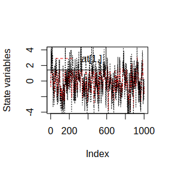

```r
plot(ans, at.idx = 1, att.idx = NA, CI = NA)
lines(a, lty = "dotted")
```

and comparision of the filtered series with the realization

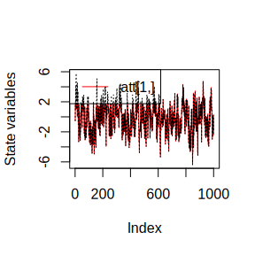

```r
plot(ans, at.idx = NA, att.idx = 1, CI = NA)
lines(a, lty = "dotted")
```

The plotting function for the fkf class also allows visual checking of whether the residuals are Gaussian

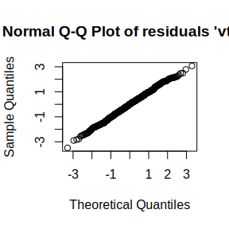

```r
plot(ans, type = "resid.qq")
```

or if there is a linear serial dependence through ‘acf’

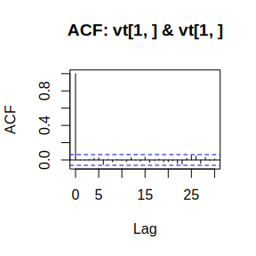

```r
plot(ans, type = "acf")
```

The smoothed estimates can also be computed by a simple call to fks

```r
sm <- fks(ans)
```

The smoothed estiamte with confidence intervals can be plotted alongside the observed data

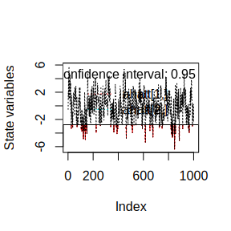

```r
plot(sm)
lines(a,col="black", lty="dotted")
```